# Risk Factor Analysis

## Outcome Variable

**Outcome Variable:** stunted

## Predictor Variables

**Intervention Variable:** single

**Adjustment Set:**

unadjusted

## Stratifying Variables

The analysis was stratified on these variable(s):

- agecat
- studyid

The following strata were considered:

- agecat: 12 months, studyid: ki0047075b-MAL-ED
- agecat: 12 months, studyid: ki1066203-TanzaniaChild2
- agecat: 12 months, studyid: ki1112895-Guatemala BSC
- agecat: 12 months, studyid: ki1126311-ZVITAMBO
- agecat: 12 months, studyid: ki1135781-COHORTS
- agecat: 18 months, studyid: ki0047075b-MAL-ED
- agecat: 18 months, studyid: ki1066203-TanzaniaChild2
- agecat: 18 months, studyid: ki1126311-ZVITAMBO
- agecat: 18 months, studyid: ki1135781-COHORTS
- agecat: 24 months, studyid: ki0047075b-MAL-ED
- agecat: 24 months, studyid: ki1066203-TanzaniaChild2
- agecat: 24 months, studyid: ki1126311-ZVITAMBO
- agecat: 24 months, studyid: ki1135781-COHORTS
- agecat: 3 months, studyid: ki0047075b-MAL-ED
- agecat: 3 months, studyid: ki1066203-TanzaniaChild2
- agecat: 3 months, studyid: ki1112895-Guatemala BSC
- agecat: 3 months, studyid: ki1126311-ZVITAMBO
- agecat: 3 months, studyid: ki1135781-COHORTS
- agecat: 6 months, studyid: ki0047075b-MAL-ED
- agecat: 6 months, studyid: ki1066203-TanzaniaChild2
- agecat: 6 months, studyid: ki1112895-Guatemala BSC
- agecat: 6 months, studyid: ki1126311-ZVITAMBO
- agecat: 6 months, studyid: ki1135781-COHORTS
- agecat: 9 months, studyid: ki0047075b-MAL-ED
- agecat: 9 months, studyid: ki1066203-TanzaniaChild2
- agecat: 9 months, studyid: ki1112895-Guatemala BSC
- agecat: 9 months, studyid: ki1126311-ZVITAMBO
- agecat: 9 months, studyid: ki1135781-COHORTS
- agecat: Birth, studyid: ki0047075b-MAL-ED
- agecat: Birth, studyid: ki1126311-ZVITAMBO
- agecat: Birth, studyid: ki1135781-COHORTS

### Dropped Strata

Some strata were dropped due to rare outcomes:

- agecat: 3 months, studyid: ki1112895-Guatemala BSC
- agecat: 6 months, studyid: ki1112895-Guatemala BSC
- agecat: 9 months, studyid: ki1112895-Guatemala BSC
- agecat: 12 months, studyid: ki1112895-Guatemala BSC
- agecat: 24 months, studyid: ki1066203-TanzaniaChild2
- agecat: 24 months, studyid: ki1126311-ZVITAMBO

## Methods Detail

We’re interested in the causal parameters $E[Y_a]$ for all values of $a \in \mathcal{A}$. These parameters represent the mean outcome if, possibly contrary to fact, we intervened to set all units to have $A=a$. Under the randomization and positivity assumptions, these are identified by the statistical parameters $\psi_a=E_W[E_{Y|A,W}(Y|A=a,W)]$. In addition, we’re interested in the mean of $Y$, $E[Y]$ under no intervention (the observed mean). We will estimate these parameters by using SuperLearner to fit the relevant likelihood factors – $E_{Y|A,W}(Y|A=a,W)$ and $p(A=a|W)$, and then updating our likelihood fit using a joint TMLE.

For unadjusted analyses ($W=\{\}$), initial likelihoods were estimated using Lrnr_glm to estimate the simple $E(Y|A)$ and Lrnr_mean to estimate $p(A)$. For adjusted analyses, a small library containing Lrnr_glmnet, Lrnr_xgboost, and Lrnr_mean was used.

Having estimated these parameters, we will then use the delta method to estimate relative risks and attributable risks relative to a prespecified baseline level of $A$.

# Results Detail

## Results Plots

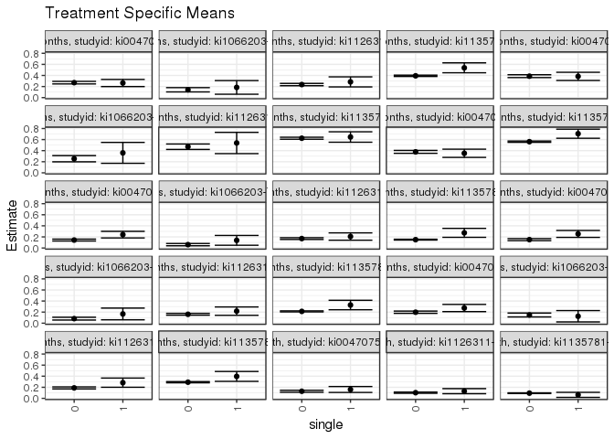

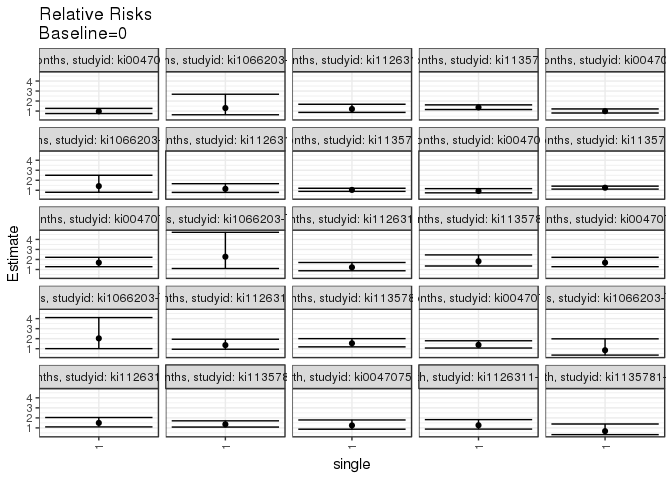

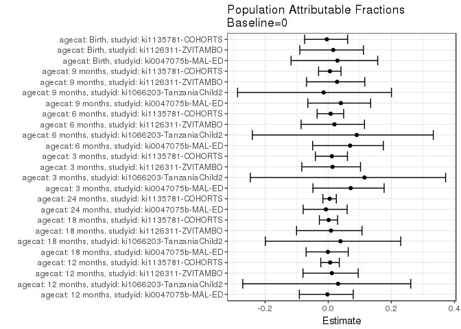

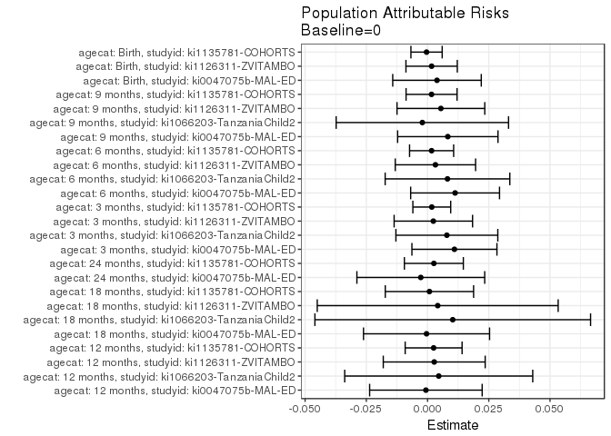

## Data Summary

| agecat | studyid | A | n | nA | nAY0 | nAY1 |
| --- | --- | --- | --- | --- | --- | --- |
| Birth | ki0047075b-MAL-ED | 0 | 1498 | 1317 | 1148 | 169 |
| Birth | ki0047075b-MAL-ED | 1 | 1498 | 181 | 152 | 29 |
| Birth | ki1066203-TanzaniaChild2 | 0 | 0 | 0 | 0 | 0 |
| Birth | ki1066203-TanzaniaChild2 | 1 | 0 | 0 | 0 | 0 |
| Birth | ki1112895-Guatemala BSC | 0 | 0 | 0 | 0 | 0 |
| Birth | ki1112895-Guatemala BSC | 1 | 0 | 0 | 0 | 0 |
| Birth | ki1126311-ZVITAMBO | 0 | 3427 | 3219 | 2889 | 330 |
| Birth | ki1126311-ZVITAMBO | 1 | 3427 | 208 | 181 | 27 |
| Birth | ki1135781-COHORTS | 0 | 8151 | 8041 | 7284 | 757 |
| Birth | ki1135781-COHORTS | 1 | 8151 | 110 | 103 | 7 |
| 3 months | ki0047075b-MAL-ED | 0 | 1776 | 1577 | 1351 | 226 |
| 3 months | ki0047075b-MAL-ED | 1 | 1776 | 199 | 151 | 48 |
| 3 months | ki1066203-TanzaniaChild2 | 0 | 569 | 511 | 480 | 31 |
| 3 months | ki1066203-TanzaniaChild2 | 1 | 569 | 58 | 50 | 8 |
| 3 months | ki1112895-Guatemala BSC | 0 | 4 | 4 | 2 | 2 |
| 3 months | ki1112895-Guatemala BSC | 1 | 4 | 0 | 0 | 0 |
| 3 months | ki1126311-ZVITAMBO | 0 | 2262 | 2117 | 1757 | 360 |
| 3 months | ki1126311-ZVITAMBO | 1 | 2262 | 145 | 115 | 30 |
| 3 months | ki1135781-COHORTS | 0 | 8360 | 8243 | 7004 | 1239 |
| 3 months | ki1135781-COHORTS | 1 | 8360 | 117 | 85 | 32 |
| 6 months | ki0047075b-MAL-ED | 0 | 1694 | 1509 | 1281 | 228 |
| 6 months | ki0047075b-MAL-ED | 1 | 1694 | 185 | 138 | 47 |
| 6 months | ki1066203-TanzaniaChild2 | 0 | 499 | 451 | 414 | 37 |
| 6 months | ki1066203-TanzaniaChild2 | 1 | 499 | 48 | 40 | 8 |
| 6 months | ki1112895-Guatemala BSC | 0 | 90 | 84 | 60 | 24 |
| 6 months | ki1112895-Guatemala BSC | 1 | 90 | 6 | 4 | 2 |
| 6 months | ki1126311-ZVITAMBO | 0 | 2041 | 1926 | 1617 | 309 |
| 6 months | ki1126311-ZVITAMBO | 1 | 2041 | 115 | 90 | 25 |
| 6 months | ki1135781-COHORTS | 0 | 8075 | 7959 | 6265 | 1694 |
| 6 months | ki1135781-COHORTS | 1 | 8075 | 116 | 78 | 38 |
| 9 months | ki0047075b-MAL-ED | 0 | 1638 | 1459 | 1170 | 289 |
| 9 months | ki0047075b-MAL-ED | 1 | 1638 | 179 | 130 | 49 |
| 9 months | ki1066203-TanzaniaChild2 | 0 | 432 | 392 | 334 | 58 |
| 9 months | ki1066203-TanzaniaChild2 | 1 | 432 | 40 | 35 | 5 |
| 9 months | ki1112895-Guatemala BSC | 0 | 60 | 57 | 38 | 19 |
| 9 months | ki1112895-Guatemala BSC | 1 | 60 | 3 | 0 | 3 |
| 9 months | ki1126311-ZVITAMBO | 0 | 1954 | 1841 | 1493 | 348 |
| 9 months | ki1126311-ZVITAMBO | 1 | 1954 | 113 | 81 | 32 |
| 9 months | ki1135781-COHORTS | 0 | 7451 | 7335 | 5195 | 2140 |
| 9 months | ki1135781-COHORTS | 1 | 7451 | 116 | 70 | 46 |
| 12 months | ki0047075b-MAL-ED | 0 | 1614 | 1436 | 1048 | 388 |
| 12 months | ki0047075b-MAL-ED | 1 | 1614 | 178 | 131 | 47 |
| 12 months | ki1066203-TanzaniaChild2 | 0 | 356 | 318 | 273 | 45 |
| 12 months | ki1066203-TanzaniaChild2 | 1 | 356 | 38 | 31 | 7 |
| 12 months | ki1112895-Guatemala BSC | 0 | 53 | 50 | 30 | 20 |
| 12 months | ki1112895-Guatemala BSC | 1 | 53 | 3 | 0 | 3 |
| 12 months | ki1126311-ZVITAMBO | 0 | 1695 | 1600 | 1223 | 377 |
| 12 months | ki1126311-ZVITAMBO | 1 | 1695 | 95 | 68 | 27 |
| 12 months | ki1135781-COHORTS | 0 | 6924 | 6805 | 4127 | 2678 |
| 12 months | ki1135781-COHORTS | 1 | 6924 | 119 | 55 | 64 |
| 18 months | ki0047075b-MAL-ED | 0 | 1544 | 1377 | 844 | 533 |
| 18 months | ki0047075b-MAL-ED | 1 | 1544 | 167 | 103 | 64 |
| 18 months | ki1066203-TanzaniaChild2 | 0 | 257 | 232 | 173 | 59 |
| 18 months | ki1066203-TanzaniaChild2 | 1 | 257 | 25 | 16 | 9 |
| 18 months | ki1112895-Guatemala BSC | 0 | 0 | 0 | 0 | 0 |
| 18 months | ki1112895-Guatemala BSC | 1 | 0 | 0 | 0 | 0 |
| 18 months | ki1126311-ZVITAMBO | 0 | 423 | 397 | 210 | 187 |
| 18 months | ki1126311-ZVITAMBO | 1 | 423 | 26 | 12 | 14 |
| 18 months | ki1135781-COHORTS | 0 | 2872 | 2773 | 1042 | 1731 |
| 18 months | ki1135781-COHORTS | 1 | 2872 | 99 | 35 | 64 |
| 24 months | ki0047075b-MAL-ED | 0 | 1487 | 1328 | 826 | 502 |
| 24 months | ki0047075b-MAL-ED | 1 | 1487 | 159 | 103 | 56 |
| 24 months | ki1066203-TanzaniaChild2 | 0 | 2 | 2 | 2 | 0 |
| 24 months | ki1066203-TanzaniaChild2 | 1 | 2 | 0 | 0 | 0 |
| 24 months | ki1112895-Guatemala BSC | 0 | 0 | 0 | 0 | 0 |
| 24 months | ki1112895-Guatemala BSC | 1 | 0 | 0 | 0 | 0 |
| 24 months | ki1126311-ZVITAMBO | 0 | 116 | 103 | 44 | 59 |
| 24 months | ki1126311-ZVITAMBO | 1 | 116 | 13 | 4 | 9 |
| 24 months | ki1135781-COHORTS | 0 | 6658 | 6539 | 2865 | 3674 |
| 24 months | ki1135781-COHORTS | 1 | 6658 | 119 | 35 | 84 |

## Results Table

### Parameter: TSM

| agecat | studyid | intervention_level | baseline_level | estimate | ci_lower | ci_upper |
| --- | --- | --- | --- | --- | --- | --- |
| Birth | ki0047075b-MAL-ED | 0 | NA | 0.1283219 | 0.1102532 | 0.1463907 |
| Birth | ki0047075b-MAL-ED | 1 | NA | 0.1602210 | 0.1067650 | 0.2136769 |
| Birth | ki1126311-ZVITAMBO | 0 | NA | 0.1025163 | 0.0920363 | 0.1129963 |
| Birth | ki1126311-ZVITAMBO | 1 | NA | 0.1298077 | 0.0841265 | 0.1754889 |
| Birth | ki1135781-COHORTS | 0 | NA | 0.0941425 | 0.0877593 | 0.1005258 |
| Birth | ki1135781-COHORTS | 1 | NA | 0.0636364 | 0.0180166 | 0.1092562 |
| 3 months | ki0047075b-MAL-ED | 0 | NA | 0.1433101 | 0.1260117 | 0.1606084 |
| 3 months | ki0047075b-MAL-ED | 1 | NA | 0.2412060 | 0.1817495 | 0.3006626 |
| 3 months | ki1066203-TanzaniaChild2 | 0 | NA | 0.0606654 | 0.0399496 | 0.0813811 |
| 3 months | ki1066203-TanzaniaChild2 | 1 | NA | 0.1379310 | 0.0491095 | 0.2267525 |
| 3 months | ki1126311-ZVITAMBO | 0 | NA | 0.1700520 | 0.1540453 | 0.1860586 |
| 3 months | ki1126311-ZVITAMBO | 1 | NA | 0.2068966 | 0.1409485 | 0.2728446 |
| 3 months | ki1135781-COHORTS | 0 | NA | 0.1503094 | 0.1425940 | 0.1580247 |
| 3 months | ki1135781-COHORTS | 1 | NA | 0.2735043 | 0.1927288 | 0.3542798 |
| 6 months | ki0047075b-MAL-ED | 0 | NA | 0.1510934 | 0.1330182 | 0.1691687 |
| 6 months | ki0047075b-MAL-ED | 1 | NA | 0.2540541 | 0.1913050 | 0.3168031 |
| 6 months | ki1066203-TanzaniaChild2 | 0 | NA | 0.0820399 | 0.0566875 | 0.1073924 |
| 6 months | ki1066203-TanzaniaChild2 | 1 | NA | 0.1666667 | 0.0611316 | 0.2722017 |
| 6 months | ki1126311-ZVITAMBO | 0 | NA | 0.1604361 | 0.1440414 | 0.1768309 |
| 6 months | ki1126311-ZVITAMBO | 1 | NA | 0.2173913 | 0.1419865 | 0.2927961 |
| 6 months | ki1135781-COHORTS | 0 | NA | 0.2128408 | 0.2038478 | 0.2218338 |
| 6 months | ki1135781-COHORTS | 1 | NA | 0.3275862 | 0.2421726 | 0.4129998 |
| 9 months | ki0047075b-MAL-ED | 0 | NA | 0.1980809 | 0.1776240 | 0.2185378 |
| 9 months | ki0047075b-MAL-ED | 1 | NA | 0.2737430 | 0.2084043 | 0.3390818 |
| 9 months | ki1066203-TanzaniaChild2 | 0 | NA | 0.1479592 | 0.1127700 | 0.1831484 |
| 9 months | ki1066203-TanzaniaChild2 | 1 | NA | 0.1250000 | 0.0223922 | 0.2276078 |
| 9 months | ki1126311-ZVITAMBO | 0 | NA | 0.1890277 | 0.1711382 | 0.2069172 |
| 9 months | ki1126311-ZVITAMBO | 1 | NA | 0.2831858 | 0.2000939 | 0.3662778 |
| 9 months | ki1135781-COHORTS | 0 | NA | 0.2917519 | 0.2813484 | 0.3021553 |
| 9 months | ki1135781-COHORTS | 1 | NA | 0.3965517 | 0.3075255 | 0.4855780 |
| 12 months | ki0047075b-MAL-ED | 0 | NA | 0.2701950 | 0.2472204 | 0.2931696 |
| 12 months | ki0047075b-MAL-ED | 1 | NA | 0.2640449 | 0.1992655 | 0.3288244 |
| 12 months | ki1066203-TanzaniaChild2 | 0 | NA | 0.1415094 | 0.1031470 | 0.1798718 |
| 12 months | ki1066203-TanzaniaChild2 | 1 | NA | 0.1842105 | 0.0607826 | 0.3076384 |
| 12 months | ki1126311-ZVITAMBO | 0 | NA | 0.2356250 | 0.2148242 | 0.2564258 |
| 12 months | ki1126311-ZVITAMBO | 1 | NA | 0.2842105 | 0.1934855 | 0.3749356 |
| 12 months | ki1135781-COHORTS | 0 | NA | 0.3935342 | 0.3819261 | 0.4051422 |
| 12 months | ki1135781-COHORTS | 1 | NA | 0.5378151 | 0.4482311 | 0.6273991 |
| 18 months | ki0047075b-MAL-ED | 0 | NA | 0.3870733 | 0.3613384 | 0.4128083 |
| 18 months | ki0047075b-MAL-ED | 1 | NA | 0.3832335 | 0.3094732 | 0.4569938 |
| 18 months | ki1066203-TanzaniaChild2 | 0 | NA | 0.2543103 | 0.1981653 | 0.3104554 |
| 18 months | ki1066203-TanzaniaChild2 | 1 | NA | 0.3600000 | 0.1714763 | 0.5485237 |
| 18 months | ki1126311-ZVITAMBO | 0 | NA | 0.4710327 | 0.4218733 | 0.5201922 |
| 18 months | ki1126311-ZVITAMBO | 1 | NA | 0.5384615 | 0.3466138 | 0.7303093 |
| 18 months | ki1135781-COHORTS | 0 | NA | 0.6242337 | 0.6062043 | 0.6422631 |
| 18 months | ki1135781-COHORTS | 1 | NA | 0.6464646 | 0.5522768 | 0.7406525 |
| 24 months | ki0047075b-MAL-ED | 0 | NA | 0.3780120 | 0.3519242 | 0.4040999 |
| 24 months | ki0047075b-MAL-ED | 1 | NA | 0.3522013 | 0.2779317 | 0.4264709 |
| 24 months | ki1135781-COHORTS | 0 | NA | 0.5618596 | 0.5498329 | 0.5738863 |
| 24 months | ki1135781-COHORTS | 1 | NA | 0.7058824 | 0.6240106 | 0.7877541 |

### Parameter: E(Y)

| agecat | studyid | intervention_level | baseline_level | estimate | ci_lower | ci_upper |
| --- | --- | --- | --- | --- | --- | --- |
| Birth | ki0047075b-MAL-ED | NA | NA | 0.1321762 | 0.1316496 | 0.1327029 |
| Birth | ki1126311-ZVITAMBO | NA | NA | 0.1041727 | 0.1039545 | 0.1043909 |
| Birth | ki1135781-COHORTS | NA | NA | 0.0937308 | 0.0936544 | 0.0938072 |
| 3 months | ki0047075b-MAL-ED | NA | NA | 0.1542793 | 0.1528428 | 0.1557158 |
| 3 months | ki1066203-TanzaniaChild2 | NA | NA | 0.0685413 | 0.0666188 | 0.0704638 |
| 3 months | ki1126311-ZVITAMBO | NA | NA | 0.1724138 | 0.1720418 | 0.1727858 |
| 3 months | ki1135781-COHORTS | NA | NA | 0.1520335 | 0.1517233 | 0.1523437 |
| 6 months | ki0047075b-MAL-ED | NA | NA | 0.1623377 | 0.1608080 | 0.1638674 |
| 6 months | ki1066203-TanzaniaChild2 | NA | NA | 0.0901804 | 0.0879888 | 0.0923719 |
| 6 months | ki1126311-ZVITAMBO | NA | NA | 0.1636453 | 0.1630754 | 0.1642152 |
| 6 months | ki1135781-COHORTS | NA | NA | 0.2144892 | 0.2141913 | 0.2147870 |
| 9 months | ki0047075b-MAL-ED | NA | NA | 0.2063492 | 0.2052057 | 0.2074927 |
| 9 months | ki1066203-TanzaniaChild2 | NA | NA | 0.1458333 | 0.1452051 | 0.1464616 |
| 9 months | ki1126311-ZVITAMBO | NA | NA | 0.1944729 | 0.1934981 | 0.1954476 |
| 9 months | ki1135781-COHORTS | NA | NA | 0.2933834 | 0.2930888 | 0.2936780 |
| 12 months | ki0047075b-MAL-ED | NA | NA | 0.2695167 | 0.2694227 | 0.2696107 |
| 12 months | ki1066203-TanzaniaChild2 | NA | NA | 0.1460674 | 0.1446958 | 0.1474390 |
| 12 months | ki1126311-ZVITAMBO | NA | NA | 0.2383481 | 0.2378159 | 0.2388803 |
| 12 months | ki1135781-COHORTS | NA | NA | 0.3960139 | 0.3955722 | 0.3964556 |
| 18 months | ki0047075b-MAL-ED | NA | NA | 0.3866580 | 0.3865985 | 0.3867175 |
| 18 months | ki1066203-TanzaniaChild2 | NA | NA | 0.2645914 | 0.2607549 | 0.2684280 |
| 18 months | ki1126311-ZVITAMBO | NA | NA | 0.4751773 | 0.4736321 | 0.4767225 |
| 18 months | ki1135781-COHORTS | NA | NA | 0.6250000 | 0.6248516 | 0.6251484 |
| 24 months | ki0047075b-MAL-ED | NA | NA | 0.3752522 | 0.3748467 | 0.3756577 |
| 24 months | ki1135781-COHORTS | NA | NA | 0.5644338 | 0.5639754 | 0.5648921 |

### Parameter: RR

| agecat | studyid | intervention_level | baseline_level | estimate | ci_lower | ci_upper |
| --- | --- | --- | --- | --- | --- | --- |
| Birth | ki0047075b-MAL-ED | 1 | 0 | 1.2485861 | 0.8692511 | 1.793460 |
| Birth | ki1126311-ZVITAMBO | 1 | 0 | 1.2662150 | 0.8777182 | 1.826669 |
| Birth | ki1135781-COHORTS | 1 | 0 | 0.6759577 | 0.3289970 | 1.388824 |
| 3 months | ki0047075b-MAL-ED | 1 | 0 | 1.6831058 | 1.2791252 | 2.214674 |
| 3 months | ki1066203-TanzaniaChild2 | 1 | 0 | 2.2736374 | 1.0969003 | 4.712759 |
| 3 months | ki1126311-ZVITAMBO | 1 | 0 | 1.2166667 | 0.8726318 | 1.696337 |
| 3 months | ki1135781-COHORTS | 1 | 0 | 1.8196091 | 1.3483193 | 2.455633 |
| 6 months | ki0047075b-MAL-ED | 1 | 0 | 1.6814367 | 1.2778914 | 2.212417 |
| 6 months | ki1066203-TanzaniaChild2 | 1 | 0 | 2.0315315 | 1.0042050 | 4.109839 |
| 6 months | ki1126311-ZVITAMBO | 1 | 0 | 1.3550021 | 0.9438399 | 1.945278 |
| 6 months | ki1135781-COHORTS | 1 | 0 | 1.5391137 | 1.1818360 | 2.004399 |
| 9 months | ki0047075b-MAL-ED | 1 | 0 | 1.3819760 | 1.0654989 | 1.792454 |
| 9 months | ki1066203-TanzaniaChild2 | 1 | 0 | 0.8448276 | 0.3594269 | 1.985755 |
| 9 months | ki1126311-ZVITAMBO | 1 | 0 | 1.4981182 | 1.1006559 | 2.039110 |
| 9 months | ki1135781-COHORTS | 1 | 0 | 1.3592088 | 1.0828403 | 1.706114 |
| 12 months | ki0047075b-MAL-ED | 1 | 0 | 0.9772385 | 0.7537634 | 1.266969 |
| 12 months | ki1066203-TanzaniaChild2 | 1 | 0 | 1.3017544 | 0.6318592 | 2.681870 |
| 12 months | ki1126311-ZVITAMBO | 1 | 0 | 1.2061985 | 0.8661251 | 1.679798 |
| 12 months | ki1135781-COHORTS | 1 | 0 | 1.3666288 | 1.1539435 | 1.618515 |
| 18 months | ki0047075b-MAL-ED | 1 | 0 | 0.9900799 | 0.8076732 | 1.213682 |
| 18 months | ki1066203-TanzaniaChild2 | 1 | 0 | 1.4155932 | 0.8019064 | 2.498925 |
| 18 months | ki1126311-ZVITAMBO | 1 | 0 | 1.1431510 | 0.7886196 | 1.657065 |
| 18 months | ki1135781-COHORTS | 1 | 0 | 1.0356132 | 0.8926700 | 1.201446 |
| 24 months | ki0047075b-MAL-ED | 1 | 0 | 0.9317197 | 0.7463192 | 1.163177 |
| 24 months | ki1135781-COHORTS | 1 | 0 | 1.2563323 | 1.1165605 | 1.413601 |

### Parameter: PAR

| agecat | studyid | intervention_level | baseline_level | estimate | ci_lower | ci_upper |
| --- | --- | --- | --- | --- | --- | --- |
| Birth | ki0047075b-MAL-ED | 0 | NA | 0.0038543 | -0.0142222 | 0.0219307 |
| Birth | ki1126311-ZVITAMBO | 0 | NA | 0.0016564 | -0.0088258 | 0.0121387 |
| Birth | ki1135781-COHORTS | 0 | NA | -0.0004117 | -0.0067954 | 0.0059720 |
| 3 months | ki0047075b-MAL-ED | 0 | NA | 0.0109692 | -0.0063887 | 0.0283271 |
| 3 months | ki1066203-TanzaniaChild2 | 0 | NA | 0.0078759 | -0.0129288 | 0.0286807 |
| 3 months | ki1126311-ZVITAMBO | 0 | NA | 0.0023618 | -0.0136491 | 0.0183728 |
| 3 months | ki1135781-COHORTS | 0 | NA | 0.0017241 | -0.0059974 | 0.0094457 |
| 6 months | ki0047075b-MAL-ED | 0 | NA | 0.0112442 | -0.0068956 | 0.0293841 |
| 6 months | ki1066203-TanzaniaChild2 | 0 | NA | 0.0081404 | -0.0173065 | 0.0335874 |
| 6 months | ki1126311-ZVITAMBO | 0 | NA | 0.0032091 | -0.0131955 | 0.0196138 |
| 6 months | ki1135781-COHORTS | 0 | NA | 0.0016484 | -0.0073496 | 0.0106463 |
| 9 months | ki0047075b-MAL-ED | 0 | NA | 0.0082683 | -0.0122205 | 0.0287572 |
| 9 months | ki1066203-TanzaniaChild2 | 0 | NA | -0.0021259 | -0.0373207 | 0.0330690 |
| 9 months | ki1126311-ZVITAMBO | 0 | NA | 0.0054452 | -0.0124709 | 0.0233612 |
| 9 months | ki1135781-COHORTS | 0 | NA | 0.0016316 | -0.0087760 | 0.0120392 |
| 12 months | ki0047075b-MAL-ED | 0 | NA | -0.0006783 | -0.0236530 | 0.0222965 |
| 12 months | ki1066203-TanzaniaChild2 | 0 | NA | 0.0045580 | -0.0338289 | 0.0429449 |
| 12 months | ki1126311-ZVITAMBO | 0 | NA | 0.0027231 | -0.0180845 | 0.0235307 |
| 12 months | ki1135781-COHORTS | 0 | NA | 0.0024797 | -0.0091368 | 0.0140962 |
| 18 months | ki0047075b-MAL-ED | 0 | NA | -0.0004153 | -0.0261503 | 0.0253197 |
| 18 months | ki1066203-TanzaniaChild2 | 0 | NA | 0.0102811 | -0.0459949 | 0.0665571 |
| 18 months | ki1126311-ZVITAMBO | 0 | NA | 0.0041446 | -0.0450391 | 0.0533283 |
| 18 months | ki1135781-COHORTS | 0 | NA | 0.0007663 | -0.0172637 | 0.0187963 |
| 24 months | ki0047075b-MAL-ED | 0 | NA | -0.0027599 | -0.0288509 | 0.0233312 |
| 24 months | ki1135781-COHORTS | 0 | NA | 0.0025742 | -0.0094613 | 0.0146096 |

### Parameter: PAF

| agecat | studyid | intervention_level | baseline_level | estimate | ci_lower | ci_upper |
| --- | --- | --- | --- | --- | --- | --- |
| Birth | ki0047075b-MAL-ED | 0 | NA | 0.0291602 | -0.1176974 | 0.1567218 |
| Birth | ki1126311-ZVITAMBO | 0 | NA | 0.0159009 | -0.0900465 | 0.1115506 |
| Birth | ki1135781-COHORTS | 0 | NA | -0.0043922 | -0.0748614 | 0.0614569 |
| 3 months | ki0047075b-MAL-ED | 0 | NA | 0.0710996 | -0.0484476 | 0.1770157 |
| 3 months | ki1066203-TanzaniaChild2 | 0 | NA | 0.1149079 | -0.2467770 | 0.3716695 |
| 3 months | ki1126311-ZVITAMBO | 0 | NA | 0.0136986 | -0.0836763 | 0.1023239 |
| 3 months | ki1135781-COHORTS | 0 | NA | 0.0113405 | -0.0407743 | 0.0608458 |
| 6 months | ki0047075b-MAL-ED | 0 | NA | 0.0692644 | -0.0494016 | 0.1745117 |
| 6 months | ki1066203-TanzaniaChild2 | 0 | NA | 0.0902685 | -0.2403257 | 0.3327468 |
| 6 months | ki1126311-ZVITAMBO | 0 | NA | 0.0196103 | -0.0859365 | 0.1148985 |
| 6 months | ki1135781-COHORTS | 0 | NA | 0.0076850 | -0.0351645 | 0.0487608 |
| 9 months | ki0047075b-MAL-ED | 0 | NA | 0.0400696 | -0.0645259 | 0.1343880 |
| 9 months | ki1066203-TanzaniaChild2 | 0 | NA | -0.0145773 | -0.2870355 | 0.2002031 |
| 9 months | ki1126311-ZVITAMBO | 0 | NA | 0.0279997 | -0.0686253 | 0.1158878 |
| 9 months | ki1135781-COHORTS | 0 | NA | 0.0055612 | -0.0305534 | 0.0404102 |
| 12 months | ki0047075b-MAL-ED | 0 | NA | -0.0025166 | -0.0914900 | 0.0792041 |
| 12 months | ki1066203-TanzaniaChild2 | 0 | NA | 0.0312046 | -0.2706836 | 0.2613705 |
| 12 months | ki1126311-ZVITAMBO | 0 | NA | 0.0114248 | -0.0798444 | 0.0949799 |
| 12 months | ki1135781-COHORTS | 0 | NA | 0.0062616 | -0.0235088 | 0.0351662 |
| 18 months | ki0047075b-MAL-ED | 0 | NA | -0.0010741 | -0.0698940 | 0.0633190 |
| 18 months | ki1066203-TanzaniaChild2 | 0 | NA | 0.0388565 | -0.1991560 | 0.2296275 |
| 18 months | ki1126311-ZVITAMBO | 0 | NA | 0.0087221 | -0.1003798 | 0.1070067 |
| 18 months | ki1135781-COHORTS | 0 | NA | 0.0012261 | -0.0280426 | 0.0296615 |
| 24 months | ki0047075b-MAL-ED | 0 | NA | -0.0073547 | -0.0793399 | 0.0598295 |
| 24 months | ki1135781-COHORTS | 0 | NA | 0.0045606 | -0.0169923 | 0.0256567 |